# Dietary Variation in the Northern Goshawk in British Columbia

# Introduction

Effective wildlife conservation often requires understanding diet composition and its consequences for population demographics (Ferrer and Negro 2004, Stier et al. 2016). Specialist predators consume a narrow range of prey species, which increases foraging efficiency on the preferred prey at the potential cost of decreased reproductive success for the specialist when that prey is scarce (Newton 1998). Generalist predators consume a greater diversity of prey and readily switch between prey species, and so are less sensitive to changes in prey abundance (Steenhof and Kochert 1988, Terraube and Arroyo 2011). However, even in a generalist predator a single key prey species can be a major driver of reproductive success (Elmhagen et al. 2000, Resano‐Mayor et al. 2016). For at-risk predators, increasing the abundance of key prey species may be a useful conservation tool (Ferrer and Negro 2004, Forsman et al. 2004, Resano‐Mayor et al. 2016).

The northern goshawk (*Accipiter gentilis*) is a large forest-dwelling raptor with a Holarctic distribution. A generalist predator, the goshawk hunts a variety of small- and medium-sized mammals and birds, including squirrels, rabbits and hares, grouse, jays and crows, and pigeons (Squires et al. 2020). Despite this diverse diet, a single prey species or narrow suite of species has a strong effect on the demographics of many goshawk populations. In the Yukon, goshawks depend on snowshoe hare (*Lepus americanus*) and show strong variation in productivity, mortality, and space use in response to cyclical changes in hare abundance (Doyle and Smith 1994). Goshawks in Scandinavia likewise rely on a single prey taxon and show changes in productivity and occupancy based on the annual abundance of four grouse species (subfamily Tetraoninae) (Tornberg et al. 2005). In contrast, goshawks in the American Southwest have a wide prey base and regularly consume some fourteen different species (Boal and Mannan 1994). Fluctuations in goshawk productivity in this region are small and driven by total prey abundance, though the most influential single species is red squirrel (*Tamiasciurus hudsonicus*) (Salafsky et al. 2007). These examples suggest the identity and influence of key prey species in such an adaptable predator may be specific to each region.

In British Columbia, Canada, the coastal population of northern goshawks is the subject of federal and provincial management which focuses on the protection of breeding habitat to increase nest site availability (COSEWIC 2013). Like many raptors, goshawks are generally considered to be limited by both nest site availability and prey abundance (Reynolds et al. 2006, Rutz et al. 2006). However, current management plans do not include protections for foraging habitat or actions to increase prey populations, in part due to a lack of knowledge regarding goshawk diet and foraging behavior in this region.

Goshawk diet in the coastal Pacific Northwest is variable, with hawks on Vancouver Island, British Columbia, consuming primarily red squirrels (Ethier 1999), whereas hawks in nearby southeast Alaska (Lewis et al. 2006) and western Washington (Bloxton 2002) consume mostly medium and large birds. The mainland coast of British Columbia is ecologically very similar to Vancouver Island and hawks in this region might be predicted to consume a similar diet to hawks on Vancouver Island. However, a gradient of forest types across the coastal mainland may produce dietary variation at finer scales. Snowshoe hare, a key prey species in many portions of the goshawk’s range, is absent from Vancouver Island, scarce on the coastal mainland, and abundant in the British Columbia interior (Nagorsen 2002). Goshawk diet on the mainland coast may reflect this variation in available prey between Vancouver Island and the mainland as well as the variation in abundance between the coast and the interior. Where coastal forest types transition to interior forest types, it is unclear how goshawk diet might respond to fine variation in prey availability and abundance. Detailed, local information on goshawk diet is necessary if limiting factors beyond nest site availability are to be included in management plans.

Here we describe the breeding season diet of northern goshawks in coastal British Columbia over a two-year period using nest cameras, egested pellets, and prey remains. We assess whether goshawk diet differs within this region between the wetter *coastal* zone and the drier *transition* zone. We further evaluate whether diet composition and diet diversity influence goshawk reproductive success.

# Methods

## Study Area and Species

In North America the northern goshawk ranges from the boreal forests of the Yukon south to the high-elevation forests of Arizona and New Mexico. Two subspecies are recognized: the widespread *atricapillus* and the restricted *laingi* (Squires et al. 2020). The *laingi* subspecies was first described on the Haida Gwaii archipelago in British Columbia and is smaller and darker than the *atricapillus* subspecies found elsewhere on the continent (Taverner 1940). The range of this subspecies is limited to the west coast of North America from southeast Alaska through mainland British Columbia and Vancouver Island, possibly as far south as Washington’s Olympic Peninsula (COSEWIC 2013). Within British Columbia the Coast Mountains form a major barrier to movement and mark the boundary between the *laingi* and *atricapillus* ranges. *A. g. laingi* is considered a species at risk in British Columbia by both the federal and provincial governments due to significant habitat loss from industrial timber harvest (Team 2008, COSEWIC 2013).

We conducted research in southwestern British Columbia, where goshawks are considered part of the *laingi* subspecies [Team (2008); COSEWIC (2013); but see Geraldes et al. (2018)). The region is characterized by rugged mountains interspersed with coastal fjords and low-lying valleys. The maritime climate supports temperate rainforest containing western redcedar (*Thuja plicata*), western hemlock (*Tsuga heterophylla*), and Douglas-fir (*Pseudotsuga menziesii*) (Meidinger and Pojar 1991). Within this region, goshawk managers have delineated a *transition zone* comprised of low-elevation valleys in the Coast Mountain Range connecting the coast and the interior (Team 2008). The narrow transition zone contains temperate rainforest ecosystems which are slightly drier than the forests found elsewhere in southwestern British Columbia, termed the *coastal zone*, and somewhat intermediate with the arid forests of the interior (Figure @ref(fig:study-area-map)). The transition zone may represent an area of overlap between the coastal *laingi* population and the interior *atricapillus* population (Team 2008).

## Data Collection

We assessed goshawk diet during the 2019 and 2020 breeding seasons through a combination of egested pellets, prey remains, and nest camera photos. Active goshawk nests were located as part of long-term population monitoring conducted by the British Columbia Ministry of Forests, Lands, Natural Resource Operations and Rural Development (FLNRORD). For detailed survey methodology see McClaren (2005). Some study sites contained active nests in both years of the study.

Prey remains and egested pellets were collected from 33 nests (2019 *n* = 18, 2020 *n* = 15). Pellets and remains were gathered from beneath active nests, from within nests after juveniles fledged, and from plucking-posts located within the site. Logistic constraints prevented more than one collection of pellets and remains at most sites, but some sites were visited multiple times. All prey remains and all pellets from a collection location (one nest or one plucking post) were combined into a single sample for each visit to that location.

Nest cameras were installed at a subset of these nests (2019 *n* = 6, 2020 *n* = 7) to record prey delivered to goshawk chicks. Nest cameras are an effective and relatively unbiased method of measuring avian diet (García-Salgado et al. 2015 , Harrison et al. 2019). However, cameras may overestimate prey deliveries because goshawks cache prey items for redelivery to the nest at a later time, which creates a risk of double-counting items. Due to the discrete nature of our data we were unable to differentiate cached, re-delivered items from new items and did not attempt to account for caching in our analysis. We also did not attempt to differentiate between prey consumed by the female at the nest and prey consumed by the chicks.

Nest cameras were digital trail cameras (Reconyx brand, UltraFire and HyperFire models) mounted 2-5 meters distant from and slightly above the nest, usually in an adjacent tree. Cameras in 2019 were programmed to take three photos one second apart when triggered by motion, and an additional one photo every thirty minutes. Cameras in 2020 were programmed to take five photos one second apart when triggered by motion, and an additional one photo every twenty minutes. Installation took place during the early nestling phase (between 4 June and 18 July; mean installation date 21 June) and cameras were left in place until after juveniles dispersed in the fall. Camera site selection was not random but constrained by topography, site access, and timing of nest discovery. We observed no nest abandonment following camera installation.

Breeding chronology was not available for most sites. At 12 of the 13 nests with cameras (2019 *n* = 6, 2020 *n* = 6), chicks were aged from photos taken shortly after camera installation using a pictorial guide (Boal 1994). Productivity was defined as the number of chicks to reach 32 days age (Boal 1994, McClaren et al. 2002).

## Diet Quantification

We reconstructed prey from pellets and prey remains following a modification of the protocol used by Lewis et al. (2004). Within each sample, remains were identified to the lowest possible taxonomic category and the minimum number of individuals counted (i.e. 3 hare femurs = 2 *Lepus americanus*). Intact pellets and broken but reassembled pellets were analyzed individually within each sample, while fragmented pellets were combined within each sample. Pellets were dissected and feathers, fur, and hard parts (bones, teeth, claws) were identified to the lowest taxonomic level. We counted the minimum number of individuals represented within the pellet or pellet collection. Prey items from pellets and remains were additionally categorized by size (small = sparrow- or vole-sized, medium = jay- or squirrel-sized, and large = grouse- or hare-sized).

Prey items identified to species were assigned a mass using data from the literature. We assigned mass to mammals from Nagorsen (2002) and to birds from Billerman et al. (2020), using the geographically closest estimates available and averaging the mass of males and females. We treated some homogenous genera for which we could not differentiate species (such as *Eutamias* and *Myotis*) as a single taxonomic grouping. For these genera, we assigned mass by averaging the masses of all possible species, based on range maps. Red squirrels (*Tamiasciurus hudsonicus*) were present at a single site within our study area; when unable to distinguish between the two members of the genus *Tamiasciurus* we assigned the item to the more common *T. douglasii*. Unidentified grouse were common among remains; these were assigned the mean mass of the two grouse species present in our study area (*Bonasa umbellus* and *Dendragapus fulignosus*). Juveniles prey items (mainly grouse) were assigned 50% of adult mass. Unidentified items were assigned mass by averaging the masses of the identified species in that size category and taxonomic class.

Data from prey remains and egested pellets are known to be biased indices of diet. Some authors have found combining data from both sources to produce relatively unbiased results that can serve as a helpful supplement to nest camera data (Simmons et al. 1991, Lewis et al. 2004). After testing for differences between pooled pellets-and-remains data and camera data we found significant differences between these two sources. We therefore report results from pellets, pooled pellets-and-remains, and cameras separately. We do not report results from prey remains alone, as diet composition estimates from prey remains are highly biased and infrequently used in raptor diet studies.

Nest camera photos were reviewed and each new prey item delivered to the nest was recorded and identified to species when possible. When items could not be identified to species, they were identified to the lowest possible taxonomic level. Prey items identified from photos were assigned a size category and biomass by the same method used for remains and pellets. Partial items were assigned the average mass for that size category and taxonomic class.

We quantified goshawk diet across the entire study area in several ways using data from pellets, pooled pellets-and-remains, and nest cameras. For ease of comparison, we simplified prey items into eight broad categories: tree squirrels (genus *Tamiasciurus*), hares (genus *Lepus*), all other mammals, grouse (subfamily Tetraoninae), thrushes (family Turdidae), corvids (family Corvidae), all other birds, and unidentified items. We calculated the relative proportion of avian and mammalian biomass, as well as the relative proportion of biomass composed of tree squirrels (genus *Tamiasciurus*), which are known to be an important source of prey for goshawks in British Columbia (Ethier 1999). For nests with cameras, we additionally quantified diet at the level of the individual nest and further calculated diet diversity with Simpson’s Diversity Index (Simpson 1949) using counts of items identified to genus or better. We report all diet quantification as percent of biomass or mean percent biomass $\pm$ the standard deviation except where counts or percents of items are explicitly specified.

## Statistical Analysis

Sites were classified as either coastal or transition based on whether the site was centered within the transition zone defined by Team (2008). We used counts of items assigned to the eight broad prey categories to assess differences in goshawk diet between the coastal and transition zones. We combined all data within each zone and tested each data source separately using a chi-squared test with simulated Monte Carlo *p*-values (2000 permutations) due to small sample sizes (Hope 1968). For nests with cameras, we also calculated the proportion of squirrel biomass and diet diversity at the individual nest level and compared these between the zones using a *t*-test. Finally, we tested for differences in goshawk productivity between the two zones using a *t*-test.

| nest | Aves | Mammalia | Tamiasciurus | bird | grouse | thrush | mammal | squirrel | unknown | corvid | hare | year |
| --- | --- | --- | --- | --- | --- | --- | --- | --- | --- | --- | --- | --- |
| TCR2019 | 32.395843 | 56.46914 | 47.90907 | 21.931184 | 8.283050 | 2.1816087 | 8.560068 | 47.90907 | 11.135020 | 0.0000000 | 0.00000 | 2019 |
| MTF2019 | 16.939927 | 71.50728 | 50.67320 | 1.056588 | 11.946743 | 0.8986939 | 20.834078 | 50.67320 | 11.552791 | 3.0379022 | 0.00000 | 2019 |
| PCR2020 | 10.479487 | 73.89067 | 60.44446 | 3.455356 | 0.000000 | 1.6413896 | 13.446210 | 60.44446 | 15.629848 | 5.3827413 | 0.00000 | 2020 |
| RLK2020 | 8.730180 | 86.01664 | 86.01664 | 0.000000 | 0.000000 | 1.0010617 | 0.000000 | 86.01664 | 5.253184 | 7.7291185 | 0.00000 | 2020 |
| UTZ2019 | 10.976765 | 87.46287 | 48.49267 | 2.232420 | 6.258430 | 0.9553851 | 6.924748 | 48.49267 | 1.560363 | 1.5305293 | 32.04546 | 2019 |
| GOW2020 | 6.689575 | 89.01918 | 49.77464 | 6.169259 | 0.000000 | 0.0000000 | 9.448694 | 49.77464 | 4.291245 | 0.5203156 | 29.79585 | 2020 |
| MTF2020 | 11.739624 | 72.50828 | 46.64115 | 5.622927 | 2.068286 | 3.4936014 | 25.867129 | 46.64115 | 15.752094 | 0.5548096 | 0.00000 | 2020 |
| FMT2020 | 35.180649 | 63.25578 | 43.88962 | 21.111978 | 9.406972 | 4.6616992 | 19.366159 | 43.88962 | 1.563575 | 0.0000000 | 0.00000 | 2020 |
| MTC2019 | 27.961341 | 60.70703 | 52.47086 | 3.884420 | 18.143488 | 5.9334335 | 8.236164 | 52.47086 | 11.331630 | 0.0000000 | 0.00000 | 2019 |
| TMC2019 | 15.337769 | 73.51088 | 25.75218 | 4.701548 | 0.000000 | 10.6362206 | 47.758697 | 25.75218 | 11.151352 | 0.0000000 | 0.00000 | 2019 |

[output cut: 3 more lines]

To determine the potential reproductive consequences of dietary variation, we examined how two aspects of diet, diet diversity and the proportion squirrel biomass in the diet, influenced productivity using linear regressions. We pooled data from both years of the study after testing for differences in prey group composition, diet diversity, proportion squirrel biomass, and productivity between years. We included all available nests in this analysis, including one site which contained an active nest in both years of the study. The presented results are not altered if variables for this site are averaged across years or a single year is randomly selected for inclusion. Because productivity data were available only from sites with nest cameras and nest-level diet data from pellets and prey remains were sparse, we performed this analysis using only diet data from nest cameras. All analyses were performed in R (Team 2020). We used a significance level of *P* = 0.05 for all tests.

# Results

## Goshawk Diet

We identified a total of 9 unique species from pellets collected at 25 nests. Of the 135 prey items obtained from pellets, 58% could be identified to genus or better and all items were identified at least to class. Of the 121 prey items obtained from remains, 51% were identified to genus or better and all items were identified at least to class. There were 18 species identified from remains collected at 30 nests, for a total of 21 unique prey species from the pooled pellets-and-remains sample (Table @ref(tab:biomass-table)).

The majority of prey identified from pellets was mammalian (75% of biomass). Squirrels made up 61% of biomass, while other birds (neither grouse, corvids, nor thrushes) made up 21%, and other mammals (neither tree squirrels nor hares) made up another 15%. The remaining 4% of biomass was made up of corvids and thrushes.

In contrast, the majority of prey (63% of biomass) identified from the combined pellets-and-remains sample was avian. The largest prey group was grouse (37%), followed by other birds (23%) and hare (18%). Squirrels made up only 14% of the combined sample. The remaining 3% of biomass was made up of corvids and thrushes.

We identified a total of 22 unique species from 518 prey deliveries recorded on 13 nest cameras (Table @ref(tab:biomass-table). After excluding 68 deliveries that were completely obscured from the cameras, each nest contributed an average of 35 items (range 1 - 69). We were able to identify 60% to genus or better, and 78% at least to class. Small and medium birds were disproportionately represented among items identified only to class, frequently arriving at the nest already plucked and decapitated. Variability in the number of items recorded and the rate of identification was due to differences in camera placement and sensitivity settings.

## Difference between ecological regions

We observed a difference in the diet of goshawks in the coastal and transition zones, although these differences were more pronounced in the camera data ($\chi$<sup>2</sup> = 23.84, *P* = 0.002) and pooled pellets-and-remains data ($\chi$<sup>2</sup> = 41.75, *P* << 0.05) than in data from pellets alone ($\chi$<sup>2</sup> = 7.53, *P* = 0.09) (Figure @ref(fig:chi-square-graph)). However, we observed no significant differences in diet diversity (mean = 0.46 $\pm$ 0.21; coastal zone mean = 0.29 $\pm$ 0.24, *n* = 5, transition zone mean = 0.54 $\pm$ 0.14, *n* = 8; *t* = -1.9, df = 4.13, *P* = 0.13) or the proportion of squirrel biomass (mean = 50 $\pm$ 14; coastal zone mean = 57 $\pm$ 20, *n* = 5, transition zone mean = 47 $\pm$ 10, *n* = 8; *t* = 1, df = 3.75, *P* = 0.38) between the zones.

## Productivity

We found little evidence to suggest goshawk productivity was impacted by either the proportion of diet composed of squirrel biomass (*F*<sub>1</sub> = 0.65, df = 9, *P* = 0.44) (Figure @ref(fig:squirrel-model-graph)) or diet diversity (*F*<sub>1</sub> = 1.31, df = 9, *P* = 0.28) (Figure @ref(fig:diversity-model-graph)). There was also no significant difference in goshawk productivity between the coastal and transition zones (*t* = 0.93, df = 4.71, *P* = 0.4).

# Discussion

Northern goshawks are considered generalist predators and consume a wide variety of prey species. Despite this, a single key prey species often contributes disproportionately to goshawk diet, and the identity of this species may be specific to each goshawk population (Doyle and Smith 1994, Ethier 1999, Tornberg et al. 2005). In coastal British Columbia we found goshawks consumed 29 different species during the breeding season. These prey ranged in size from tiny bats (~ 6 grams) to grouse larger than the goshawks themselves (~ 1000 grams). However, the majority of their diet was composed of tree squirrels of the genus *Tamiasciurus*. Across the entire study area this single taxa made up approximately half of the total biomass recorded. Individual nests varied in the degree to to which they specialized on tree squirrels, with some nests consuming as little as 26% squirrel biomass and others as much as 86%. Despite the clear importance of tree squirrels in the diet, the proportion of squirrel biomass delivered to the nest did not influence northern goshawk fledging success.

Goshawk survival, migration, reproductive success, and other demographic parameters are often related to the abundance of a key prey species (Doyle and Smith 1994, Tornberg et al. 2005, Rutz and Bijlsma 2006). Although we lacked data on prey abundance within our study area, other authors have found goshawk diet does reflect site-level prey abundance (Lewis et al. 2006, Rogers et al. 2006). We observed significant variation in the proportion of tree squirrel biomass delivered to each nest, which may reflect differences in squirrel abundance between sites. However, we did not find evidence to support an effect of this variation on goshawk productivity. When key prey abundance is low, high diet diversity may indicate a reliance on alternate prey and associated negative reproductive consequences (Resano‐Mayor et al. 2016), but we found no evidence of an effect of diet diversity on goshawk productivity. Notably, the only nest in our study to experience a complete breeding failure received the smallest proportion of squirrel biomass we observed. Given the strength of evidence from other studies and the clear importance of tree squirrels in the diet of this population, it seems probable tree squirrel abundance has some affect on goshawk productivity. Tree squirrels experience large fluctuations in abundance following cyclical changes in conifer seed crop size (Smith 1970). Given the potential cascading consequences for goshawks, understanding the relationship between tree squirrel abundance and goshawk demography remains a crucial knowledge gap.

Across much of North America the key goshawk prey species is usually mammalian, often from the family Leporidae or Sciuridae (Boal and Mannan 1994, Doyle and Smith 1994, DeStefano et al. 2006, Rogers et al. 2006, Miller et al. 2014). However, in the coastal temperate rainforests of the Pacific Northwest, goshawk diet generally contains more birds than mammals and the key prey is usually a species of grouse (subfamily Tetraoninae) (Watson et al. 1998, Thrailkill et al. 2000, Bloxton 2002, Lewis et al. 2006). Despite inhabiting coastal rainforests, goshawks on Vancouver Island, British Columbia, consume primarily red squirrels (*T. hudsonicus*) (Ethier 1999). Our results from the coastal mainland of British Columbia are consistent with findings from Vancouver Island and more broadly with results from the interior of North America, but stand in contrast to findings from elsewhere in the Pacific Northwest. Goshawk diet varies at large scales in response to available prey species and prey abundance (Drennan 2006), suggesting tree squirrel abundance is higher within Vancouver Island and the south coast than other temperate rainforest ecosystems.

Raptor diet is studied through a variety of indirect methods, such as the collection of pellets and prey remains, and direct methods, such as nest cameras and observation from blinds. Nest cameras are considered one of the least biased methods for measuring diet at the nest in raptors (Tornberg and Reif 2007, García-Salgado et al. 2015, Harrison et al. 2019). Cameras in this study provided significantly more data at a finer resolution than either pellets or prey remains, which could only be collected during the infrequent surveys each site received. However, the cost, effort, and logistical challenges of camera installation restricted the number of sites from which camera data could be collected. Additionally, technical issues relating to camera settings and placement resulted in a loss of data at some sites. Despite these limitations, we believe nest cameras provided the most accurate and complete picture of goshawk diet. Compared to cameras, pellets were relatively unbiased in measuring coarse diet composition, but severely underestimated prey species richness. The pooled pellets-and-remains sample captured a much greater prey richness, including several species not detected on nest cameras, but greatly overestimated the proportion of avian biomass relative to camera data. Measuring diet composition by counts or biomass adds further uncertainty, with measurements of counts overestimating avian prey relative to measurements of biomass. These complex results highlight the importance of clearly reporting the source and measurement of raptor diet data. Because these methods have all been used in past studies we believe there is value in reporting the results of each for ease of comparison. However, we advocate for future diet studies to prioritize the collection of data via cameras, either video or still images, rather than physical specimens.

Our study addresses a fundamental question regarding the basic ecology of an at-risk population of the northern goshawk. This population is currently considered part of *A. g. laingi*, a subspecies restricted to the coastal Pacific Northwest. In portions of *laingi*’s range the diet is dominated by mammalian prey, specifically tree squirrels[Ethier (1999); this study], and in other by avian prey (Bloxton 2002, Lewis et al. 2006). Tree squirrels clearly play a key role in the diet of some *laingi* populations, including the population of Haida Gwaii (Roberts 1997, cited in COSEWIC (2013)), where red squirrel is an introduced species. Genetic evidence indicates goshawks on this isolated archipelago may be distinct from goshawks on the mainland coast and Vancouver Island (Sonsthagen et al. 2012, Geraldes et al. 2018). Regardless of their taxonomic relationship, dietary evidence suggests the goshawk populations of Haida Gwaii, Vancouver Island, and southwestern British Columbia are more similar to each other in foraging habits than to other putative *laingi* populations. Ecological similarity, such as diet and habitat characteristics, may therefore prove a better guide than genetic similarity when when incorporating foraging habitat or prey populations into management plans.

# Figures

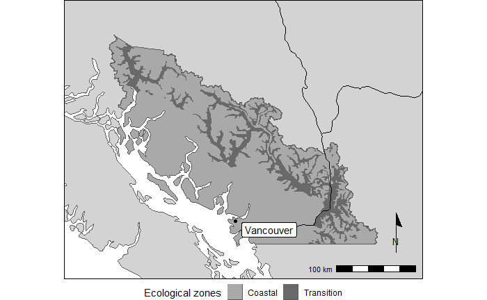

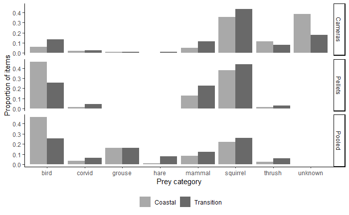

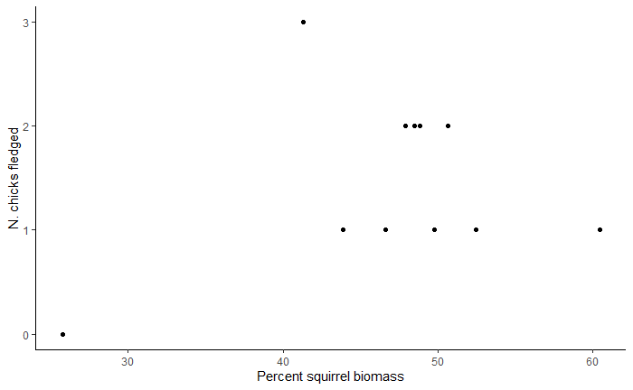

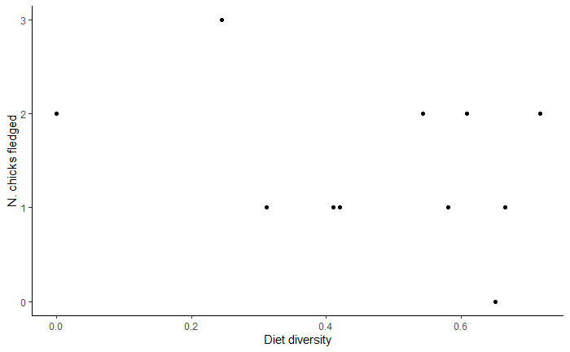

[output not shown]

1camera  
2pellets  
3remains

# Literature Cited

Billerman, S. M., B. K. Keeney, P. G. Rodewald, and T. S. Schulenberg, editors. 2020. Birds of the World. Cornell Lab of Ornithology, Ithaca, NY, USA. <https://birdsoftheworld-org.proxy.lib.sfu.ca/bow/home>.

Bloxton, T. D., Jr. 2002. Prey Abundance, Space Use, Demography, and Foraging Habitat of Northern Goshawks in Western Washington. Master’s thesis, University of Washington, Seattle, WA.

Boal, C. W. 1994. A Photographic and Behavioral Guide to Aging Nestling Northern Goshawks. Studies in Avian Biology 16:32–40.

Boal, C. W., and R. W. Mannan. 1994. Northern Goshawk Diets in Ponderosa Pine Forests on the Kaibab Plateau. 16:97–102.

COSEWIC. 2013. COSEWIC assessment and status report on the Northern Goshawk *Accipiter gentilis laingi* in Canada. Committee on the Status of Endangered Wildlife in Canada, Ottawa, ON. <[http://www.sararegistry.gc.ca/virtual_sara/files/cosewic/sr_autour _palombes_northern_goshawk_1213_e.pdf](http://www.sararegistry.gc.ca/virtual_sara/files/cosewic/sr_autour%20_palombes_northern_goshawk_1213_e.pdf)>.

DeStefano, S., M. T. McGrath, S. K. Daw, and S. M. Desimone. 2006. Ecology and habitat of breeding Northern Goshawks in the inland Pacific Northwest: A summary of research in the 1990s. Studies in Avian Biology 31:75–84. <http://pubs.er.usgs.gov/publication/70028410>. Accessed 18 Sep 2018.

Doyle, F. I., and J. M. N. Smith. 1994. Population responses of northern goshawks to the 10-year cycle in numbers of snowshoe hares. Studies in Avian Biology 16:122–129.

Elmhagen, B., M. Tannerfeldt, P. Verucci, and A. Angerbjörn. 2000. The arctic fox (*Alopex lagopus*): An opportunistic specialist. Journal of Zoology 251:139–149. <http://zslpublications.onlinelibrary.wiley.com/doi/abs/10.1111/j.1469-7998.2000.tb00599.x>. Accessed 15 Dec 2020.

Ethier, T. J. 1999. Breeding Ecology and Habitat of Northern Goshawks (*Accipiter gentilis laingi*) on Vancouver Island: A Hierarchical Approach. PhD, University of Victoria, Victoria, BC.

Ferrer, M., and J. J. Negro. 2004. The Near Extinction of Two Large European Predators: Super Specialists Pay a Price. Conservation Biology 18:344–349. <http://conbio.onlinelibrary.wiley.com/doi/abs/10.1111/j.1523-1739.2004.00096.x>. Accessed 15 Dec 2020.

Forsman, E. D., R. G. Anthony, E. C. Meslow, and C. J. Zabel. 2004. Diets and Foraging Behavior of Northern Spotted Owls in Oregon. Journal of Raptor Research 38:214–230.

García-Salgado, G., S. Rebollo, L. Pérez-Camacho, S. Martínez-Hesterkamp, A. Navarro, and J.-M. Fernández-Pereira. 2015. Evaluation of Trail-Cameras for Analyzing the Diet of Nesting Raptors Using the Northern Goshawk as a Model. PLoS ONE 10.

Geraldes, A., K. K. Askelson, E. Nikelski, F. I. Doyle, W. L. Harrower, K. Winker, and D. E. Irwin. 2018. Population genomic analyses reveal a highly differentiated and endangered genetic cluster of northern goshawks (*Accipiter gentilis laingi*) in Haida Gwaii. Evolutionary Applications 1–16. <https://onlinelibrary.wiley.com/doi/abs/10.1111/eva.12754>. Accessed 15 Jan 2019.

Harrison, J. T., M. N. Kochert, B. P. Pauli, and J. A. Heath. 2019. Using Motion-Activated Trail Cameras to Study Diet and Producttvity of Cliff-Nesting Golden Eagles. Journal of Raptor Research 53:26–37.

Hope, A. C. A. 1968. A Simplified Monte Carlo Significance Test Procedure. Journal of the Royal Statistical Society. Series B (Methodological) 30:582–598. <http://www.jstor.org/stable/2984263>. Accessed 26 Mar 2021.

Lewis, S. B., M. R. Fuller, and K. Titus. 2004. A Comparison of 3 Methods for Assessing Raptor Diet during the Breeding Season. Wildlife Society Bulletin 32:373–385. <http://www.jstor.org/stable/3784978>. Accessed 17 Sep 2018.

Lewis, S. B., K. Titus, and M. R. Fuller. 2006. Northern goshawk diet during the nesting season in southeast Alaska. The Journal of Wildlife Management 70:1151–1160. <https://onlinelibrary.wiley.com/doi/abs/10.2193/0022-541X%282006%2970%5B1151%3ANGDDTN%5D2.0.CO%3B2>. Accessed 4 Sep 2018.

McClaren, E. L. 2005. Northern Goshawk (*Accipiter gentilis laingi*) population inventory summary for Vancouver Island, British Columbia 1994-2002. Ministry of Environment, Victoria, BC.

McClaren, E. L., P. L. Kennedy, and S. R. Dewey. 2002. Do some northern goshawk nest areas consistently fledge more young than others? The Condor 104:343–352. <http://www.jstor.org/stable/1370036>. Accessed 30 Apr 2019.

Meidinger, D., and J. Pojar. 1991. Ecosystems of British Columbia. Ministry of Forests, Victoria, BC.

Miller, R. A., J. D. Carlisle, and M. J. Bechard. 2014. Effects of prey abundance on breeding season diet of northern goshawks (*Accipiter gentilis*) within an unusual prey landscape. Journal of Raptor Research 48:1–12. <http://www.bioone.org.proxy.lib.sfu.ca/doi/abs/10.3356/0892-1016-48.1.1>. Accessed 2 Oct 2018.

Nagorsen, D., W. 2002. An Identification Manual to the Small Mammals of British Columbia. British Columbia Ministry of Water, Land; Air Protection, Biodiversity Branch, Victoria, BC.

Newton, I. 1998. Population Limitation in Birds. Academic Press, San Diego.

Resano‐Mayor, J., J. Real, M. Moleón, J. A. Sánchez‐Zapata, L. Palma, and A. Hernández‐Matías. 2016. Diet–demography relationships in a long‐lived predator: From territories to populations. Oikos 125:262–270. <https://onlinelibrary-wiley-com.proxy.lib.sfu.ca/doi/10.1111/oik.02468>. Accessed 14 Dec 2020.

Reynolds, R. T., J. D. Wiens, and S. R. Salafsky. 2006. A Review and Evaluation of Factors Limiting Northern Goshawk Populations. Studies in Avian Biology 31:260–273.

Rogers, A. S., S. DeStefano, and M. F. Ingraldi. 2006. Diet. Prey delivery rates, and prey biomass of northern goshawks in east-central Arizona. Studies in Avian Biology 31:221–229.

Rutz, C., and R. G. Bijlsma. 2006. Food-Limitation in a Generalist Predator. Proceedings: Biological Sciences 273:2069–2076. <http://www.jstor.org/stable/25223567>. Accessed 2 Apr 2021.

Rutz, C., R. G. Bijlsma, M. Marquiss, and R. E. Kenward. 2006. Population limitation in the Northern Goshawk in Europe: A review with case studies. Studies in Avian Biology 31:158–197.

Salafsky, S. R., R. T. Reynolds, B. R. Noon, and J. A. Wiens. 2007. Reproductive Responses of Northern Goshawks to Variable Prey Populations. The Journal of Wildlife Management 71:2274–2283. <http://wildlife.onlinelibrary.wiley.com/doi/abs/10.2193/2006-357>. Accessed 3 Sep 2020.

Simmons, R., D. M. Avery, and G. Avery. 1991. Biases in diets determined from pellets and remains: Correction factors for a mammal and bird-eating raptor. Journal of Raptor Research 25:63–67.

Simpson, E. H. 1949. Measurement of Diversity. Nature 163:688–688. <http://www.nature.com/articles/163688a0>. Accessed 30 Dec 2020.

Sonsthagen, S. A., E. L. McClaren, F. I. Doyle, K. Titus, G. K. Sage, R. E. Wilson, J. R. Gust, and S. L. Talbot. 2012. Identification of metapopulation dynamics among Northern Goshawks of the Alexander Archipelago, Alaska, and Coastal British Columbia. Conservation Genetics 13:1045–1057. <https://doi.org/10.1007/s10592-012-0352-z>. Accessed 2 Oct 2018.

Squires, J. R., R. T. Reynolds, J. Orta, and J. S. Marks. 2020. Northern Goshawk (Accipiter gentilis). S. M. Billerman, editor. Birds of the World. version 1.0. Cornell Lab of Ornithology, Ithaca, NY, USA. <https://doi-org.proxy.lib.sfu.ca/10.2173/bow.norgos.01>. Accessed 9 Nov 2020.

Steenhof, K., and M. N. Kochert. 1988. Dietary responses of three raptor species to changing prey densities in a natural environment. Journal of Animal Ecology 57:37–48. <http://www.jstor.org/stable/4761>. Accessed 1 Apr 2019.

Stier, A. C., J. F. Samhouri, M. Novak, K. N. Marshall, E. J. Ward, R. D. Holt, and P. S. Levin. 2016. Ecosystem context and historical contingency in apex predator recoveries. Science Advances 2:e1501769. <https://advances-sciencemag-org.proxy.lib.sfu.ca/content/2/5/e1501769>. Accessed 2 Apr 2021.

Taverner, P. A. 1940. Variation in the American Goshawk. The Condor 42:157–160. <https://academic.oup.com/condor/article/42/3/157/5251119>. Accessed 9 Nov 2020.

Team, N. G. R. 2008. Recovery strategy for the Northern Goshawk, laingi subspecies (Accipiter gentilis laingi) in British Columbia. B.C. Ministry of Environment, Victoria, BC. <http://a100.gov.bc.ca/pub/eirs/viewDocumentDetail.do?fromStatic=true&repository=BDP&documentId=7811>.

Team, R. C. 2020. R: A language and environment for statistical computing. R Foundation for Statistical Computing, Vienna. Austria. <https://www.R-project.org/>.

Terraube, J., and B. Arroyo. 2011. Factors influencing diet variation in a generalist predator across its range distribution. Biodiversity and Conservation 20:2111–2131. <https://doi.org/10.1007/s10531-011-0077-1>. Accessed 29 Apr 2019.

Thrailkill, J. A., L. S. Andrews, and R. M. Claremont. 2000. Diet of Breeding Northern Goshawks in the Coast Range of Oregon. Journal of Raptor Research 34:339–340.

Tornberg, R., E. Korpimäki, S. Jungell, and V. Reif. 2005. Delayed numerical response of goshawks to population fluctuations of forest grouse. Oikos 111:408–415.

Tornberg, R., and V. Reif. 2007. Assessing the diet of birds of prey: A comparison of prey items found in nests and images. Ornis Fennica 84:21–31.

Watson, J. W., D. W. Hays, S. P. Finn, and P. Meehan. 1998. Prey of breeding northern goshawks in Washington. Journal of Raptor Research 32:397–305.